# CSDE 533 R Lab #3

Sarah Kilpatrick

2025-02-09

# **Problem 1:** Using `tidycensus` data - 50 points

Install and load the package into your environment.

```
## To install your API key for use in future sessions, run this function with `install = TRUE`.
```

Pick a county in the U.S. to explore:

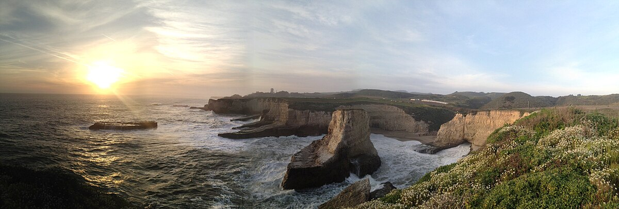

The North Coast of Santa Cruz, California

I’m choosing Santa Cruz County, California. It is one of the oldest counties in California surrounded by the Pacific Ocean and the Santa Cruz Mountains. It is home to old-growth coastal redwoods and a wealth of biological diversity, protected by a variety of state parks. I grew up hiking and camping in these mountains, and my aunt and uncle live in Santa Cruz.

It is also known for its University of California - Santa Cruz (UCSC) Campus; the area has been experiencing growing pains in the past few decades, and there is a lack of housing for the mounting student body. There is a reluctance from non-student constituents to urbanize or create higher-density housing, causing a housing shortage for everyone.

## **(a) 10 points**

Present a table that includes a caption with the county’s population count and total housing unit count in 2010 and 2020.

With code provided by Jess Godwin from CSDE 533’s 3rd R lab:

```r
get_census_data = function(year) {
  #ITS P001001 IF IN 2010, P1_001N IF IN 2020
  pop_var = ifelse(year == 2020, "P1_001N", "P001001")
  hu_var = ifelse(year == 2020, "H1_001N", "H001001")

  #population data grabber
  pop_data <- get_decennial(geography = "county",
                            variables = pop_var,
                            year = year,
                            sumfile = "pl",
                            state = 06,
                            county = 087,
                            geometry = FALSE,
                            key = myKey) %>%
    rename(Population = value) %>%
    select(GEOID, NAME, Population)

  #housing units grabber
  hu_data <- get_decennial(geography = "county",
                           variables = hu_var,
                           year = year,
                           sumfile = "pl",
                           state = 06,
                           county = 087,
                           geometry = FALSE,
                           key = myKey) %>%
    rename(Total_Housing_Units = value) %>%
    select(GEOID, NAME, Total_Housing_Units)

  # Merge both for the table
  combined_data = left_join(pop_data, hu_data, by = c("GEOID", "NAME"))
  # Add year column
  combined_data$Year = year
  return(combined_data)
}

# call fn for both sets
data_2010 = get_census_data(2010)
```

```
## Using the PL 94-171 Redistricting Data Summary File
```

```
## Using the PL 94-171 Redistricting Data Summary File
```

```r
data_2020 = get_census_data(2020)
```

```
## Using the PL 94-171 Redistricting Data Summary File
```

[output not shown]

```r
final_table = bind_rows(data_2010, data_2020) %>%
  select(Year, Population, Total_Housing_Units)

kable(final_table,
      col.names = c("Year", "Population", "Total Housing Units"),
      caption = "Santa Cruz County, California, Population & Housing Units (2010 vs. 2020)") %>%
  kable_styling(font_size = 15,
                bootstrap_options = c("striped", "condensed")) %>%
  scroll_box(width = "600px", height = "300px")
```

Santa Cruz County, California, Population & Housing Units (2010 vs. 2020)

| Year | Population | Total Housing Units |
| --- | --- | --- |
| 2010 | 262382 | 104476 |
| 2020 | 270861 | 106345 |

## **(b) 10 points**

Under the assumption of exponential growth, calculate the growth rate $R$, for both population and housing units in your county of choice. Present the growth rates in a table with a caption and comment on the comparison between the two calculations.

```r
# Extract the population and housing data from final_table
pop10 = final_table$Population[final_table$Year == 2010]
pop20 = final_table$Population[final_table$Year == 2020]
housing10 = final_table$Total_Housing_Units[final_table$Year == 2010]
housing20 = final_table$Total_Housing_Units[final_table$Year == 2020]

t = 10

# Calculate exponential growth rates
R_pop = (log(pop20) - log(pop10)) / t
R_housing = (log(housing20) - log(housing10)) / t

growth_table = data.frame(
  Metric = c("Population Growth Rate", "Housing Unit Growth Rate"),
  Growth_Rate = c(R_pop, R_housing)
)

kable(growth_table,
      col.names = c("", ""),
      digits = 5,
      caption = "Annual Exponential Growth Rates (2010 vs. 2020) in Santa Cruz County") %>%
  kable_styling(font_size = 15,
                bootstrap_options = c("striped", "condensed")) %>%
  scroll_box(width = "600px", height = "300px")
```

Annual Exponential Growth Rates (2010 vs. 2020) in Santa Cruz County

| Population Growth Rate | 0.00318 |
| --- | --- |
| Housing Unit Growth Rate | 0.00177 |

```r
## 2020 redistricting file
decennial_red_vars <- load_variables(year = 2020, dataset = "pl")

## 2020 Demographic & Housing Characteristics file
decennial_dhc_vars <- load_variables(year = 2020, dataset = "dhc")

## 2020 Demographic Profile file
decennial_dp_vars <- load_variables(year = 2020, dataset = "dp")

## ACS 5-year 2018-2022: for tracts
acs5_2022_vars <- load_variables(year = 2022, dataset = "acs1")
```

## **(c) 10 points**

Using the American Community Survey, get the estimates of total population and housing units for your county between 2010-2023 in years that do not have a decennial Census. Create a two plots, one each for population and housing units, that contains years on the $x$-axis and population or housing unit totals on the $y$-axis. In years where data comes from ACS, add vertical error bars around the estimate point to represent the 90% confidence interval.

The population data lacks error bars because there are no margins of error, the ACS felt it had recorded the population accurately enough for this to not require MOE’s. This will also be why the next part will have nulls in the CI width for the population column. The housing, however, contains margins or error, so that data is present.

```r
# Function to get ACS estimates for total population and housing units
get_acs_data <- function(year, table) {
  get_acs(
    geography = "county",
    table = table,
    year = year,
    geometry = FALSE,
    survey = "acs1",
    state = 06,
    county = 087
  ) %>%
    mutate(Year = year) %>%
    relocate("Year", .after = "GEOID")
}

# Years to fetch data (excluding decennial Census years)
acs_years = c(2011:2019, 2021, 2022)

# Get population data
pop_data_list = lapply(acs_years, get_acs_data, table = "B01001")
```

[output not shown]

[output not shown]

[output not shown]

[output not shown]

[output not shown]

[output not shown]

[output not shown]

[output not shown]

[output not shown]

[output not shown]

[output not shown]

[output not shown]

[output not shown]

[output not shown]

[output not shown]

[output not shown]

[output not shown]

[output not shown]

[output not shown]

[output not shown]

[output not shown]

[output not shown]

```r
pop_data = bind_rows(pop_data_list)

# Get housing unit data
housing_data_list = lapply(acs_years, get_acs_data, table = "B25001")
```

[output not shown]

[output not shown]

[output not shown]

[output not shown]

[output not shown]

[output not shown]

[output not shown]

[output not shown]

[output not shown]

[output not shown]

[output not shown]

[output not shown]

[output not shown]

[output not shown]

[output not shown]

[output not shown]

[output not shown]

[output not shown]

[output not shown]

[output not shown]

[output not shown]

[output not shown]

```r
housing_data = bind_rows(housing_data_list)
```

[figure not shown]

```r
pop_summary = pop_data %>%
  group_by(Year) %>%
  summarize(Population = sum(estimate), MOE = sqrt(sum(moe^2)))

housing_summary = housing_data %>%
  group_by(Year) %>%
  summarize(HousingUnits = sum(estimate), MOE = sqrt(sum(moe^2)))

# Plot population with error bars
ggplot(pop_summary, aes(x = Year, y = Population)) +
  geom_point() +
  geom_errorbar(aes(ymin = Population - MOE, ymax = Population + MOE), width = 0.2) +
  scale_x_continuous(breaks = seq(min(acs_years), max(acs_years), by = 1)) +
  labs(title = "King County Population Estimates (ACS 1-Year)",
       x = "Year",
       y = "Population") +
  theme_minimal()
```

[figure not shown]

```r
# Plot housing units with error bars
ggplot(housing_summary, aes(x = Year, y = HousingUnits)) +
  geom_point() +
  geom_errorbar(aes(ymin = HousingUnits - MOE, ymax = HousingUnits + MOE), width = 0.2) +
  scale_x_continuous(breaks = seq(min(acs_years), max(acs_years), by = 1)) +
  labs(title = "King County Housing Unit Estimates (ACS 1-Year)",
       x = "Year",
       y = "Housing Units") +
  theme_minimal()
```

## **(d) 10 points**

Using the American Community Survey, get the estimates of total population and housing units for Census tracts within your county for two periods between 2010-2023.

According to [this data dictionary,](https://www.geoplan.ufl.edu/agol/metadata/htm/cenacs_2013.htm) Total Population = B01003_001 Housing Units = B25001_001

[output not shown]

[output not shown]

[output not shown]

[output not shown]

[output not shown]

[output not shown]

[output not shown]

[output not shown]

1. Calculate the mean 90% confidence interval width for each variable and time period across tracts, and present your calculations in a table.

Average CI Widths in ACS Tract Data; Santa Cruz County, CA

| Period | Population | Housing |
| --- | --- | --- |
| 2012-2016 | 0 | 1280 |
| 2018-2022 | 0 | 432 |

2. Comment on the comparison between the 90% CI widths for the county-level estimates and the tract-level mean 90% CI widths for each variable and time period.

The tract-level housing unit CI width decreased significantly from 2012-2016 to 2018-2022 (from 1,280 to 432). This could be because the ACS methods for assessment (data collection, statistical analysis) improved, which could have reduced the margins of error.

Overall, there is an increase in total housing units, though not by much, and a relatively slow exponential growth rate of 0.00177 for housing.

## **(e) 10 points**

Using the `load_variables` function, find a categorical variable in the ACS that is of interest to you that is not total housing units or total population. Report the estimate and 80%, 90%, and 95% confidence intervals for this variable in a table whose caption accurately describes what the variable/estimate represents and for what period in time it applies.

I chose this variable in row 367: B02001_008 Estimate!!Total:!!**Two or More Races**: Race

I am using the same years as before, 2010-2022, excluding years of the decennial census: 2010 and 2020.

This is a specific enough variable to have margins of error.

```r
# Get ACS data for "total estimate two or more races"

twoplus_raw <- lapply(acs_years, function(year) {
  get_acs(
    geography = "county",
    variables = "B02001_008",
    year = year,
    state = "06",
    county = "087",
    survey = "acs1",
    key = myKey
  ) %>% mutate(Year = year)
}) %>%
  bind_rows() %>%
  # reorders year first
  select(Year, everything())
```

[output not shown]

[output not shown]

[output not shown]

[output not shown]

[output not shown]

[output not shown]

[output not shown]

[output not shown]

[output not shown]

[output not shown]

[output not shown]

```r
# twoplus_raw
```

```r
# Compute Confidence Intervals
z_80 = qnorm(0.10, lower.tail = FALSE)  # 80% CI z-score
z_90 = qnorm(0.05, lower.tail = FALSE)  # 90% CI z-score
z_95 = qnorm(0.025, lower.tail = FALSE) # 95% CI z-score

# twoplus_se_ci

twoplus_se_ci = twoplus_raw %>%
  mutate(
    # Standard Error from 90% MOE
    SE = moe / z_90,
    CI_80_Lower = estimate - z_80 * SE,
    CI_80_Upper = estimate + z_80 * SE,
    CI_90_Lower = estimate - z_90 * SE,
    CI_90_Upper = estimate + z_90 * SE,
    CI_95_Lower = estimate - z_95 * SE,
    CI_95_Upper = estimate + z_95 * SE
  ) %>%
  select(Year, estimate, CI_80_Lower, CI_80_Upper, CI_90_Lower, CI_90_Upper, CI_95_Lower, CI_95_Upper)

kable(twoplus_se_ci,
    caption = "Population of Individuals Reporting 2 or More Races in Santa Cruz County, CA (ACS 1-Year Estimates)",
    col.names = c("Year", "Estimate", "80% CI Lower", "80% CI Upper",
                  "90% CI Lower", "90% CI Upper", "95% CI Lower", "95% CI Upper"),
    digits = 0
  ) %>%
  kable_styling(font_size = 15, bootstrap_options = c("striped", "condensed")) %>%
  scroll_box(width = "600px", height = "300px")
```

Population of Individuals Reporting 2 or More Races in Santa Cruz County, CA (ACS 1-Year Estimates)

| Year | Estimate | 80% CI Lower | 80% CI Upper | 90% CI Lower | 90% CI Upper | 95% CI Lower | 95% CI Upper |
| --- | --- | --- | --- | --- | --- | --- | --- |
| 2011 | 9064 | 7670 | 10458 | 7275 | 10853 | 6932 | 11196 |
| 2012 | 12254 | 10676 | 13832 | 10229 | 14279 | 9841 | 14667 |
| 2013 | 12188 | 10071 | 14305 | 9471 | 14905 | 8950 | 15426 |
| 2014 | 11610 | 10074 | 13146 | 9639 | 13581 | 9261 | 13959 |
| 2015 | 12929 | 11388 | 14470 | 10951 | 14907 | 10572 | 15286 |
| 2016 | 11586 | 9805 | 13367 | 9300 | 13872 | 8862 | 14310 |
| 2017 | 12379 | 10887 | 13871 | 10464 | 14294 | 10097 | 14661 |
| 2018 | 13055 | 11491 | 14619 | 11048 | 15062 | 10664 | 15446 |
| 2019 | 13868 | 12199 | 15537 | 11726 | 16010 | 11316 | 16420 |
| 2021 | 43255 | 39218 | 47292 | 38073 | 48437 | 37080 | 49430 |
| 2022 | 42661 | 38374 | 46948 | 37159 | 48163 | 36105 | 49217 |

**Recall:** A confidence interval is constructed as
$$\bar{x} \pm z_{(1-\alpha/2)} \times
SE(\bar{x})$$
or
$$\hat{p} \pm
z_{(1-\alpha/2)} \times SE(\hat{p}),$$
where $\alpha = (100 - \mbox{confidence level})/100$ and $z_{1 - \alpha/2}$ can be calculated in `R` as below.

# **Problem 2:** Population Pyramids - 25 points

## **(a) 10 points**

For your county selected in Problem 1, create a population pyramid using a method we went over in lab in each decennial census year 2010 and 2020. Comment on the general shapes of each plot and the changes, if any, between them.

First, we must pre-process the data. The two decennial censuses have different variables to define the age groups, by sex. For example, the 2020 data dictionary can be found [here](https://api.census.gov/data/2020/dec/dhc/groups/P12.html). The 2010 data dictionary is the same except for the lacking underscore and “N” at the end.

```r
p12_vars_2010 = c("P012003", "P012004", "P012005", "P012006", "P012007", "P012008", "P012009",
  "P012010", "P012011", "P012012", "P012013", "P012014", "P012015", "P012016",
  "P012017", "P012018", "P012019", "P012020", "P012021", "P012022", "P012023",
  "P012024", "P012025", "P012027", "P012028", "P012029", "P012030", "P012031",
  "P012032", "P012033", "P012034", "P012035", "P012036", "P012037", "P012038",
  "P012039", "P012040", "P012041", "P012042", "P012043", "P012044", "P012045",
  "P012046", "P012047", "P012048", "P012049"
)

sc_age_sex_2010 = get_decennial(
  geography = "county",
  variables = p12_vars_2010,
  year = 2010,
  sumfile = "sf1",
  state = "06",
  county = "087",
  geometry = FALSE,
  key = myKey
)
```

```
## Using Census Summary File 1
```

```r
sc_age_sex_2010$value = as.numeric(sc_age_sex_2010$value)

sc_agebysex_2010 = sc_age_sex_2010 %>%
  # Filter for relevant P12 variables (Male: P012003-P012025, Female: P012027-P012049)
  filter(variable %in% p12_vars_2010) %>%
  mutate(
    # Assign Male/Female based on variable codes
    Sex = ifelse(as.numeric(substr(variable, 6, 8)) <= 25, "Male", "Female"),

    # Assign Age Groups
    Age_Group = case_when(
      variable %in% c("P012003", "P012027") ~ "0-4",
      variable %in% c("P012004", "P012028") ~ "5-9",
      variable %in% c("P012005", "P012029") ~ "10-14",
      variable %in% c("P012006", "P012007", "P012030", "P012031") ~ "15-19",
      variable %in% c("P012008", "P012009", "P012010", "P012032", "P012033", "P012034") ~ "20-24",
      variable %in% c("P012011", "P012035") ~ "25-29",
      variable %in% c("P012012", "P012036") ~ "30-34",
      variable %in% c("P012013", "P012037") ~ "35-39",
      variable %in% c("P012014", "P012038") ~ "40-44",
      variable %in% c("P012015", "P012039") ~ "45-49",
      variable %in% c("P012016", "P012040") ~ "50-54",
      variable %in% c("P012017", "P012041") ~ "55-59",
      variable %in% c("P012018", "P012019", "P012042", "P012043") ~ "60-64",
      variable %in% c("P012020", "P012021", "P012044", "P012045") ~ "65-69",
      variable %in% c("P012022", "P012046") ~ "70-74",
      variable %in% c("P012023", "P012047") ~ "75-79",
      variable %in% c("P012024", "P012048") ~ "80-84",
      variable %in% c("P012025", "P012049") ~ "85+",
      TRUE ~ "Unknown"
    )
  ) %>%
  # Group by Age Group and Sex
  group_by(Age_Group, Sex) %>%
  summarise(Total_Population = sum(value, na.rm = TRUE), .groups = "drop") %>%
  mutate(Age_Group = factor(Age_Group, levels = c(
    "0-4", "5-9", "10-14", "15-19", "20-24", "25-29",
    "30-34", "35-39", "40-44", "45-49", "50-54", "55-59",
    "60-64", "65-69", "70-74", "75-79", "80-84", "85+"
  ))) %>%
  arrange(Age_Group, Sex)

# sc_agebysex_2010
```

```r
p12_vars_2020 = c(
  "P12_003N", "P12_004N", "P12_005N", "P12_006N", "P12_007N",
  "P12_008N", "P12_009N", "P12_010N", "P12_011N", "P12_012N",
  "P12_013N", "P12_014N", "P12_015N", "P12_016N", "P12_017N",
  "P12_018N", "P12_019N", "P12_020N", "P12_021N", "P12_022N",
  "P12_023N", "P12_024N", "P12_025N", "P12_027N", "P12_028N",
  "P12_029N", "P12_030N", "P12_031N", "P12_032N", "P12_033N",
  "P12_034N", "P12_035N", "P12_036N", "P12_037N", "P12_038N",
  "P12_039N", "P12_040N", "P12_041N", "P12_042N", "P12_043N",
  "P12_044N", "P12_045N", "P12_046N", "P12_047N", "P12_048N",
  "P12_049N"
)

sc_age_sex_2020 = get_decennial(
  geography = "county",
  variables = p12_vars_2020,
  year = 2020,
  sumfile = "dhc",  # DHC is the SF1 equivalent in 2020
  state = "06",
  county = "087",
  geometry = FALSE,
  key = myKey
)
```

```
## Using the Demographic and Housing Characteristics File
```

```r
# Process the 2020 Census Age-Sex Data
sc_agebysex_2020 = sc_age_sex_2020 %>%
  # Filter for relevant P12 variables (Male: P12_003N-P12_025N, Female: P12_027N-P12_049N)
  filter(variable %in% p12_vars_2020) %>%
  mutate(
    # Assign Male/Female based on variable codes
    Sex = ifelse(as.numeric(substr(variable, 5, 7)) <= 25, "Male", "Female"),

    # Assign Age Groups
    Age_Group = case_when(
      variable %in% c("P12_003N", "P12_027N") ~ "0-4",
      variable %in% c("P12_004N", "P12_028N") ~ "5-9",
      variable %in% c("P12_005N", "P12_029N") ~ "10-14",
      variable %in% c("P12_006N", "P12_007N", "P12_030N", "P12_031N") ~ "15-19",
      variable %in% c("P12_008N", "P12_009N", "P12_010N", "P12_032N", "P12_033N", "P12_034N") ~ "20-24",
      variable %in% c("P12_011N", "P12_035N") ~ "25-29",
      variable %in% c("P12_012N", "P12_036N") ~ "30-34",
      variable %in% c("P12_013N", "P12_037N") ~ "35-39",
      variable %in% c("P12_014N", "P12_038N") ~ "40-44",
      variable %in% c("P12_015N", "P12_039N") ~ "45-49",
      variable %in% c("P12_016N", "P12_040N") ~ "50-54",
      variable %in% c("P12_017N", "P12_041N") ~ "55-59",
      variable %in% c("P12_018N", "P12_019N", "P12_042N", "P12_043N") ~ "60-64",
      variable %in% c("P12_020N", "P12_021N", "P12_044N", "P12_045N") ~ "65-69",
      variable %in% c("P12_022N", "P12_046N") ~ "70-74",
      variable %in% c("P12_023N", "P12_047N") ~ "75-79",
      variable %in% c("P12_024N", "P12_048N") ~ "80-84",
      variable %in% c("P12_025N", "P12_049N") ~ "85+",
      TRUE ~ "Unknown"
    )
  ) %>%
  # Group by Age Group and Sex
  group_by(Age_Group, Sex) %>%
  summarise(Total_Population = sum(value, na.rm = TRUE), .groups = "drop") %>%
  mutate(Age_Group = factor(Age_Group, levels = c(
    "0-4", "5-9", "10-14", "15-19", "20-24", "25-29",
    "30-34", "35-39", "40-44", "45-49", "50-54", "55-59",
    "60-64", "65-69", "70-74", "75-79", "80-84", "85+"
  ))) %>%
  arrange(Age_Group, Sex)

# sc_agebysex_2020
```

**Males = blue** **Females = purple.**

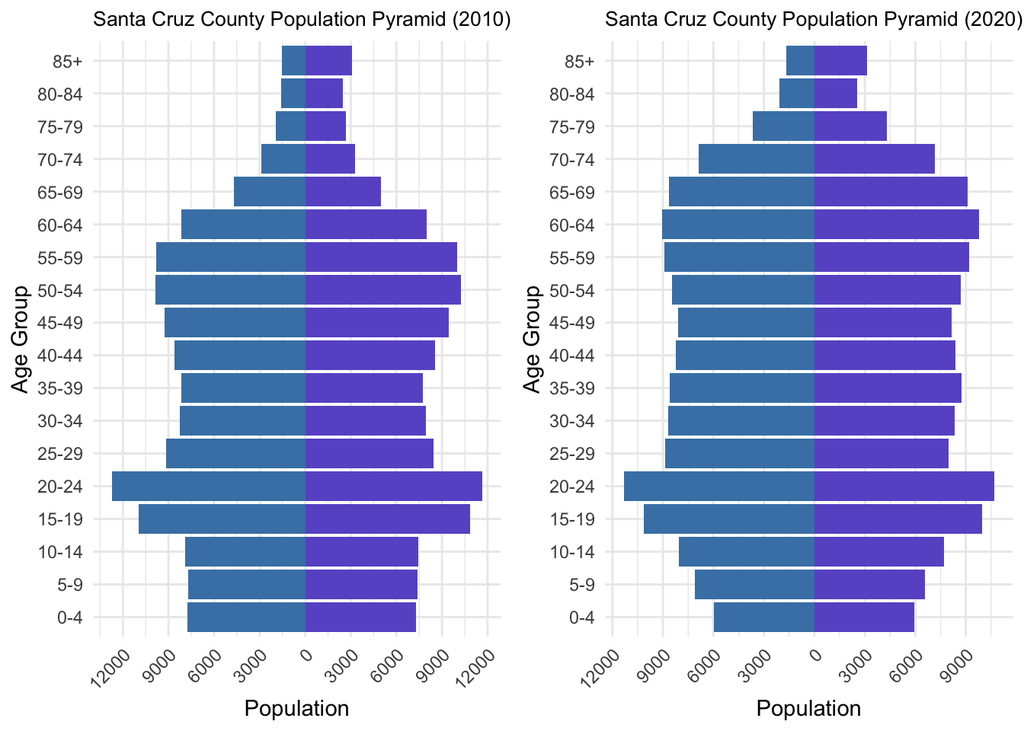

```r
sc_agebysex_2010 = sc_agebysex_2010 %>%
  mutate(Pop_plot = ifelse(Sex == "Male", -Total_Population, Total_Population))

sc_agebysex_2020 = sc_agebysex_2020 %>%
  mutate(Pop_plot = ifelse(Sex == "Male", -Total_Population, Total_Population))

pyramid_plot = function(data, year) {
  ggplot(data, aes(x = Age_Group, y = Pop_plot, fill = Sex)) +
    geom_bar(stat = "identity") +
    scale_y_continuous(
      labels = abs,
      breaks = seq(-12000, 12000, by = 3000)) +
    coord_flip() +
    theme_minimal() +
    theme(
      axis.text.x = element_text(angle = 45, hjust = 1),
      plot.title = element_text(size = 10),
      legend.title = element_blank()
    ) +
    labs(
      x = "Age Group", y = "Population",
      fill = "Sex", title = paste("Santa Cruz County Population Pyramid (", year, ")", sep = "")
    ) +
    scale_fill_manual(values = c("Male" = "steelblue", "Female" = "slateblue"))
}

pyramid_2010 = pyramid_plot(sc_agebysex_2010, "2010") + theme(legend.position = "none")
pyramid_2020 = pyramid_plot(sc_agebysex_2020, "2020")  + theme(legend.position = "none")

grid.arrange(arrangeGrob(pyramid_2010, pyramid_2020, ncol = 2))
```

Both the 2010 and 2020 pyramids show the bump of college-age individuals (18-24) for both male and female populations due to the university campus in Santa Cruz.

The squeeze in the middle-aged workforce population can be attributed partly to Santa Cruz’s hesitance to urbanizing. From personal experience, many in the SC workforce commute into the county from surrounding areas: Santa Clara County, San Mateo County, and Monterey County being some of the most densely populated in the state of California, which all direct neighbors to SC.

## **(b) 10 points**

For your county selected in Problem 2, create a population pyramid using a method we went over in lab in 2023.

This is how to read the variables for acs: 001: Total Population 002: Total Male Population 003 - 025: Male Age Groups 026: Total Female Population 027 - 049: Female Age Groups

```r
sc_raw2023 = get_acs(geography = "county",
                   table = "B01001", # Pop by sex & age
                   year = 2023,
                   geometry = FALSE,
                   survey = "acs1",
                   state = 06,
                   county = 087,
                   key = myKey)
```

```
## The 1-year ACS provides data for geographies with populations of 65,000 and greater.
```

```
## Loading ACS1 variables for 2023 from table B01001. To cache this dataset for faster access to ACS tables in the future, run this function with `cache_table = TRUE`. You only need to do this once per ACS dataset.
```

```r
sc_agebysex2023 = sc_raw2023 %>%
                                          # Male Age Groups
  filter(variable %in% c(paste0("B01001_", sprintf("%03d", 3:25)),
                                          # Female Age Groups
                         paste0("B01001_", sprintf("%03d", 27:49)))) %>%
  mutate(
    # assign Male/Female based on variable codes
    Sex = ifelse(as.numeric(substr(variable, 8, 10)) <= 25, "Male", "Female"),
    Age_Group = case_when(
      variable %in% c("B01001_003", "B01001_027") ~ "0-4",
      variable %in% c("B01001_004", "B01001_028") ~ "5-9",
      variable %in% c("B01001_005", "B01001_029") ~ "10-14",
      variable %in% c("B01001_006", "B01001_007", "B01001_030", "B01001_031") ~ "15-19",
      variable %in% c("B01001_008", "B01001_009", "B01001_010", "B01001_032", "B01001_033", "B01001_034") ~ "20-24",
      variable %in% c("B01001_011", "B01001_035") ~ "25-29",
      variable %in% c("B01001_012", "B01001_036") ~ "30-34",
      variable %in% c("B01001_013", "B01001_037") ~ "35-39",
      variable %in% c("B01001_014", "B01001_038") ~ "40-44",
      variable %in% c("B01001_015", "B01001_039") ~ "45-49",
      variable %in% c("B01001_016", "B01001_040") ~ "50-54",
      variable %in% c("B01001_017", "B01001_041") ~ "55-59",
      variable %in% c("B01001_018", "B01001_019", "B01001_042", "B01001_043") ~ "60-64",
      variable %in% c("B01001_020", "B01001_021", "B01001_044", "B01001_045") ~ "65-69",
      variable %in% c("B01001_022", "B01001_046") ~ "70-74",
      variable %in% c("B01001_023", "B01001_047") ~ "75-79",
      variable %in% c("B01001_024", "B01001_048") ~ "80-84",
      variable %in% c("B01001_025", "B01001_049") ~ "85+",
      TRUE ~ "Unknown"
    )
  ) %>%
  # Group by Age Group and Sex
  group_by(Age_Group, Sex) %>%

  summarise(
    Total_Population = sum(estimate, na.rm = TRUE),
    Total_MOE = sqrt(sum(moe^2, na.rm = TRUE)),
    .groups = "drop"
  ) %>%
  # summarise(Total_Population = sum(estimate, na.rm = TRUE), .groups = "drop") %>%
  mutate(Age_Group = factor(Age_Group, levels = c(
    "0-4", "5-9", "10-14", "15-19", "20-24", "25-29",
    "30-34", "35-39", "40-44", "45-49", "50-54", "55-59",
    "60-64", "65-69", "70-74", "75-79", "80-84", "85+"
  ))) %>%
  arrange(Age_Group, Sex)

# sc_agebysex2023
```

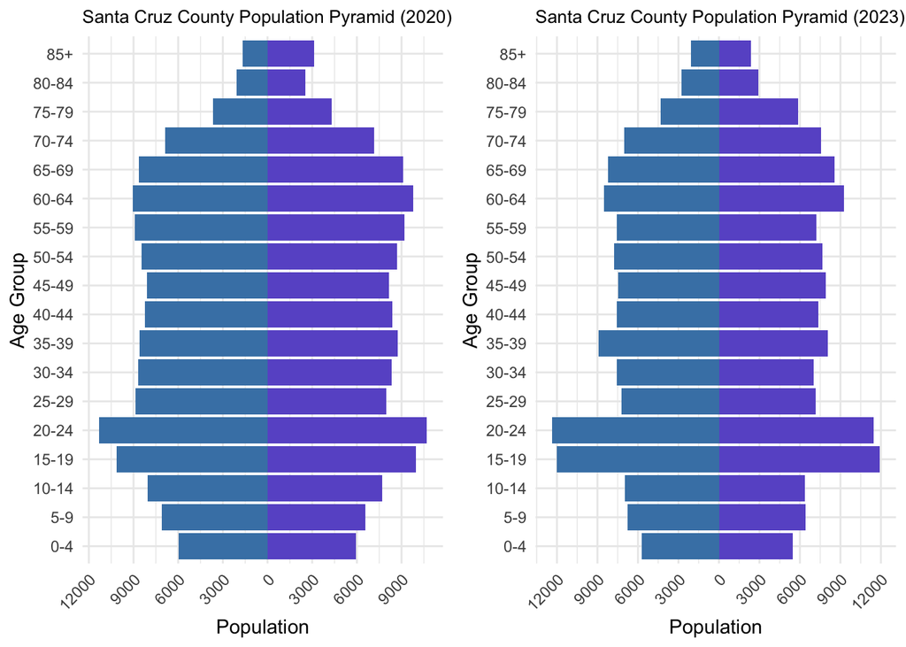

```r
sc_agebysex2023 = sc_agebysex2023 %>%
  mutate(Pop_plot = ifelse(Sex == "Male", -Total_Population, Total_Population))

pyramid_2023 = pyramid_plot(sc_agebysex2023, "2023") + theme(legend.position = "none")

grid.arrange(arrangeGrob(pyramid_2020, pyramid_2023, ncol = 2))
```

This comparison between the 2020 and 2023 population compositions of Santa Cruz show a very small decline in the youngest ages, from years 0-4 and 5-9. This could possibly point to a drop in birth rates in Santa Cruz County.

The college-age population remains similar; if anything, it has gone up over time. This shows that there will always be at least some demand for housing in the area, even if other age groups decline.

## **(c) 5 points**

In any way you can think of, display the bounds of the 90% confidence intervals on the age-specific population estimates in (b) within the population pyramid figure. This could be adding error bars or additional bars to the existing plot, or expanding the figure to a multi-panel figure.

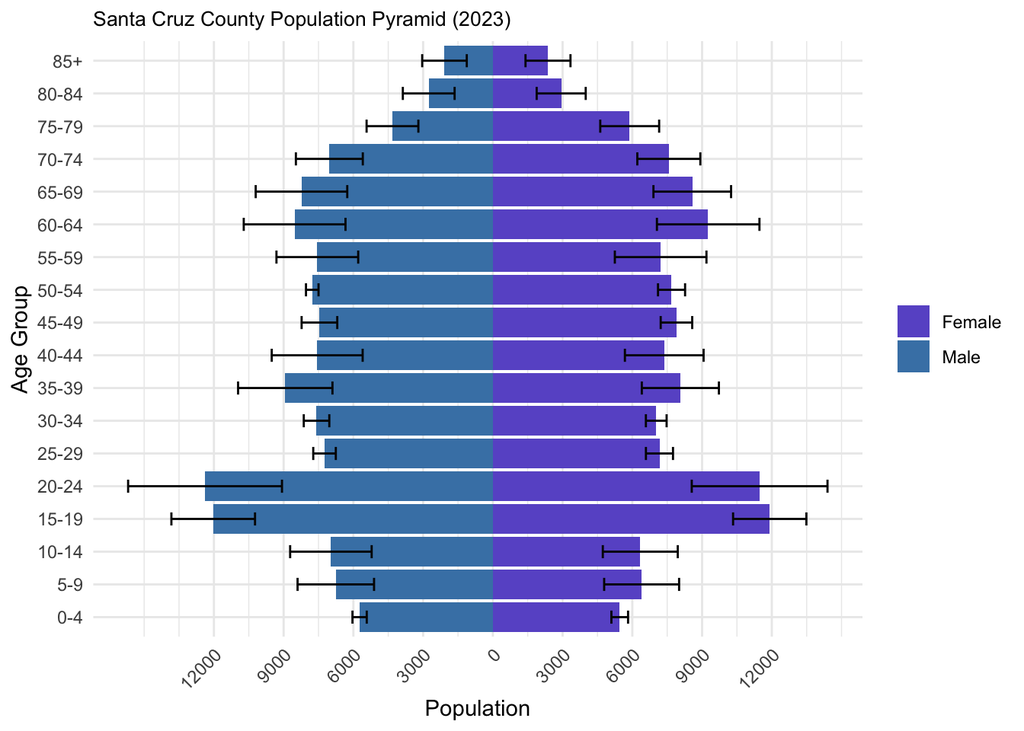

```r
pyramid_plot = function(data, year) {
  ggplot(data, aes(x = Age_Group, y = Pop_plot, fill = Sex)) +
    geom_bar(stat = "identity") +  # Main bars
    geom_errorbar(aes(ymin = Lower_CI, ymax = Upper_CI), width = 0.4, color = "gray1") +
    scale_y_continuous(labels = abs,
                       breaks = c(-12000, -9000, -6000, -3000, 0, 3000, 6000, 9000, 12000)) +
    coord_flip() +
    theme_minimal() +
    theme(
      axis.text.x = element_text(angle = 45, hjust = 1),
      plot.title = element_text(size = 10),
      legend.title = element_blank()
    ) +
    labs(
      x = "Age Group", y = "Population",
      fill = "Sex", title = paste("Santa Cruz County Population Pyramid (", year, ")", sep = "")
    ) +
    scale_fill_manual(values = c("Male" = "steelblue", "Female" = "slateblue"))
}

sc_agebysex2023 = sc_agebysex2023 %>%
  mutate(
    Pop_plot = ifelse(Sex == "Male", -Total_Population, Total_Population),
    Lower_CI = ifelse(Sex == "Male", -(Total_Population - 1.645 * Total_MOE), Total_Population - 1.645 * Total_MOE),
    Upper_CI = ifelse(Sex == "Male", -(Total_Population + 1.645 * Total_MOE), Total_Population + 1.645 * Total_MOE)
  )

# Generate the updated population pyramid plot with confidence intervals
pyramid_2023 = pyramid_plot(sc_agebysex2023, "2023")
pyramid_2023
```

# **Problem 3:** Using DHS data - 25 points

Apply for DHS approval for a single country and topic of your choice, and download the data for a single survey.

## **(a) 5 points**

Read through the appendix on sampling design in the Final Report for your country and survey year. Summarize the sampling description, i.e. what are the strata and the clusters? who within a household is interviewed in the survey? were urban or rural areas oversampled?

This problem will use the [DHS Program model datasets](https://dhsprogram.com/data/Download-Model-Datasets.cfm?flag=1). Going from the Model Datasets Full Report Tables and Sampling Errors (English and French), the **Sample Design pdf** (named zzfulltables.zip) contains information for sample implementation for women and men, the coverage of HIV testing from social characteristics/demographics for women and men, and the coverage of HIV testing from sexual behavior for women and men.

*Sampling Design:* Overall, the sampling design separates households and elegible individuals by residence (urban, rural) and region (1-4). The selected households retain a status, whether the individuals completed the interview, whether no such interview could be completed, etc., or even if the dwelling exists/is vacant.

*Source:* This data comes from model DHS 6 data. *Strata:* Individuals are separated by sex and residence (urban, rural), and whether they provided blood for HIV testing. *Clusters:* The respondents are also grouped by marital status, type of union, status of sexual intercourse, status of pregnancy, time slept away/time away from home in last 12 months, ethnic group, and religion.

*Were urban/rural areas oversampled?* For both women and men rural households were sampled about twice as much as urban households. The household response rates for both sexes was above 98%.

## **(b) 5 points**

Using the Individual Recode (IR) file, create a barplot of the number of women interviewed by their birth cohort and whether their households are in urban or rural areas where the color of the bars represents urban/rural status.

According to the [DHS 6 Recode Manual](https://www.dhsprogram.com/pubs/pdf/DHSG4/Recode6_DHS_22March2013_DHSG4.pdf), all variables beginning with “v” are for women respondents. Men’s responses are from variables beginning with “mv”. Therefore there is no need to filter for sex before beginning. See Section W01 (page 33) and Section M01 (page 118) for more information.

```r
# v010 - Year of birth of respondent (see note on imputed dates)
# v011 - Century month code of date of birth of the respondent (see note on century month codes).
# v015 - Result of individual interview. Code 1 represents a completed interview. For all other cases, only REC01 will exist in the data file. For flat format data files, cases with a result code different than 1 are dropped from the file.
# v025 - whether the surveyed household was stratified as urban or rural; 1 is "urban" and 2 is "rural"

ir_file = read_dta("/Users/sarahkilpatrick/Documents/CSDE 533 Labs/ZZIR62FL.DTA") %>%
  select(caseid, v010, v011, v015, v025) %>%
  # completed interviews only
  filter(v015 == 1)

# urban residence
urban_ir_file = ir_file %>%
  filter(v025 == 1)

#rural residence
urban_ir_file = ir_file %>%
  filter(v025 == 2)
```

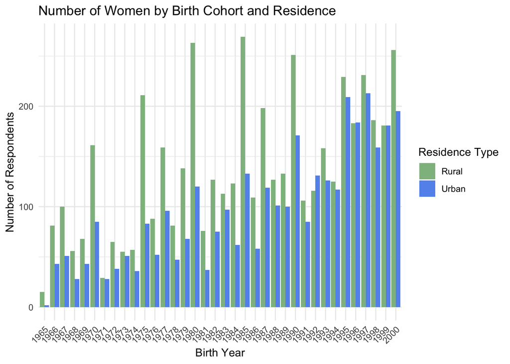

```r
ir_file = ir_file %>%
  mutate(Residence = ifelse(v025 == 1, "Urban", "Rural"))

ggplot(ir_file, aes(x = as.factor(v010), fill = Residence)) +
  geom_bar(position = "dodge") +
  labs(title = "Number of Women by Birth Cohort and Residence",
       x = "Birth Year",
       y = "Number of Respondents",
       fill = "Residence Type") +
  theme_minimal() +
  theme(axis.text.x = element_text(angle = 45, hjust = 1)) +
  scale_fill_manual(values = c("Urban" = "cornflowerblue", "Rural" = "darkseagreen"))
```

## **(c) 5 points**

Select a variable of interest to you in the Individual Recode file (IR) from the Recode Manual. Report the variable name in the file, what the survey question was in English, and the possible responses.

For the purposes of the model data, the sample survey question was in English.

**Variable:** - *v113* Major source of drinking water for members of the household. Individual codes are country specific, but the major categories are standard.

I considered the following before choosing: - *v113* Major source of drinking water for members of the household. Individual codes are country specific, but the major categories are standard. - *v116* Type of toilet facility in the household. Individual codes are country-specific, but the major categories are standard. - *v120* whether household has a radio - *V149* Educational achievement recodes the education of the respondent into the following categories: None, incomplete primary, complete primary, incomplete secondary, complete secondary, higher education.

```r
ir_file_var = read_dta("/Users/sarahkilpatrick/Documents/CSDE 533 Labs/ZZIR62FL.DTA") %>%
  select(caseid, v001, v002, v005, v010, v015, v024, v025, v113) %>%
  # completed interviews only
  filter(v015 == 1)

# attr(ir_file_var$v113, "labels")
# ir_file_var
```

**Possible Outcomes - Water Source variable v113**

piped water: 10 piped into dwelling: 11 piped to yard/plot: 12 public tap/standpipe: 13 tube well water: 20 tube well or borehole: 21 dug well (open/protected): 30 protected well: 31 unprotected well: 32 surface water: 40 protected spring: 41 unprotected spring: 42 river/dam/lake/ponds/stream/canal/irrigation channel: 43 rainwater: 51 tanker truck: 61 cart with small tank: 62 bottled water or sachets: 71 other: 96 not a dejure resident: 97

## **(d) 10 points**

Calculate the mean prevalence of each outcome to your variable of choice within the sample. Then, use the following code to calculate the proper prevalence estimates for the population that account for the survey design. Present both calculations in a table, comment on the differences you see.

```r
# unique_values <- unique(ir_file_var$v113)
# print(unique_values)

water_prevalence = ir_file_var %>%
  group_by(v113) %>%
  summarise(
    count = n(),
    # converts to percentage
    prevalence = round((count / nrow(ir_file_var)) * 100, 4)
  ) %>%
  # sorts by highest prevalence
  arrange(desc(prevalence))
```

```r
ir_file_var = ir_file_var %>% filter(!is.na(v005) & !is.na(v113))
ir_file_var$v113 = as.factor(ir_file_var$v113)

ir_file_var$v005 <- ir_file_var$v005 / 1e6

mysvy_des <- svydesign(
  ids = ~v001 + v002,
  strata = ~v024 + v025,
  weights = ~v005,
  data = ir_file_var
)

proper_prevalence = svymean(~v113, design = mysvy_des, na.rm = TRUE)

# Convert weighted prevalence to a dataframe
proper_df = data.frame(
  v113 = names(proper_prevalence),
  # Convert to percentage
  proper_prevalence = as.numeric(proper_prevalence) * 100
)
```

```r
proper_df$v113 = gsub("^v113", "", proper_df$v113)

# merge both by 'Water Source'
comparison_table = merge(water_prevalence, proper_df, by = "v113", all = TRUE)

colnames(comparison_table) = c("Water_Source", "Responder_Count", "Mean_Prevalence_Percentage", "Proper_Prevalence_Percentage")
```

```r
# str(comparison_table$Water_Source)

water_labels <- c(
  "10" = "Piped water",
  "11" = "Piped into dwelling",
  "12" = "Piped to yard/plot",
  "13" = "Public tap/standpipe",
  "20" = "Tube well water",
  "21" = "Tube well or borehole",
  "30" = "Dug well (open/protected)",
  "31" = "Protected well",
  "32" = "Unprotected well",
  "40" = "Surface water",
  "41" = "Protected spring",
  "42" = "Unprotected spring",
  "43" = "River/dam/lake/pond/stream/canal/irrigation channel",
  "51" = "Rainwater",
  "61" = "Tanker truck",
  "62" = "Cart with small tank",
  "71" = "Bottled water or sachets",
  "96" = "Other",
  "97" = "Not a de jure resident"
)

comparison_table <- comparison_table %>%
  mutate(Water_Source = as.character(Water_Source)) %>%  # Convert factor to character
  mutate(Water_Source = water_labels[Water_Source])  # Map values using water_labels

kable(comparison_table,
      col.names = c("DHS-Provided Water Source", "Total Count", "Mean Prevalence (In % of Total", "Proper Prevalence Adjusted for Survey Design (In % of Total)"),
      digits = 2,
      caption = "Mean vs. Proper Prevalence of Water-Source Outcomes from DHS-Provided Sample") %>%
  kable_styling(font_size = 15,
                bootstrap_options = c("striped", "condensed")) %>%
  scroll_box(width = "600px", height = "300px")
```

Mean vs. Proper Prevalence of Water-Source Outcomes from DHS-Provided Sample

| DHS-Provided Water Source | Total Count | Mean Prevalence (In % of Total | Proper Prevalence Adjusted for Survey Design (In % of Total) |
| --- | --- | --- | --- |
| Piped into dwelling | 103 | 1.23 | 1.79 |
| Piped to yard/plot | 225 | 2.70 | 5.05 |
| Public tap/standpipe | 1311 | 15.70 | 23.10 |
| Tube well or borehole | 1143 | 13.69 | 12.83 |
| Protected well | 2126 | 25.47 | 20.81 |
| Unprotected well | 710 | 8.51 | 7.36 |
| Protected spring | 109 | 1.31 | 1.31 |
| Unprotected spring | 1024 | 12.27 | 11.21 |
| River/dam/lake/pond/stream/canal/irrigation channel | 1364 | 16.34 | 13.65 |
| Rainwater | 54 | 0.65 | 0.50 |
| Tanker truck | 9 | 0.11 | 0.07 |
| Cart with small tank | 4 | 0.05 | 0.08 |
| Bottled water or sachets | 136 | 1.63 | 2.15 |
| Other | 17 | 0.20 | 0.09 |
| NA | 13 | 0.16 | NA |